# Exploring Annotation

Sifan Zhang

2024-12-09

**In this workflow we will compare unsupervised annotation with reference-based annotation** **For reference annotation we will use Azimuth pipeline** **guidelines can be found in [Azimuth annotation](https://satijalab.github.io/azimuth/articles/run_azimuth_tutorial.html)**

# Prepare r packages

“azimuth” and “SeuratData” need to be downloaded from github, it’s for reference annonation. Downloading could pop up errors, just keep trying installing packages that’s missing.

`devtools::install_github("satijalab/seurat", "seurat5")` `devtools::install_github("satijalab/seurat-data", "seurat5")` `remotes::install_github('satijalab/azimuth', ref = 'master')`

```r
library(devtools)
library(remotes)
library(SeuratData)
library(SeuratWrappers)
library(Azimuth)
library(SeuratObject)
library(Seurat)
library(Matrix)
library(ggplot2)
library(cowplot)
library(dplyr)
library(tidyr)
library(RColorBrewer)
library(reshape2)
library(pheatmap)
```

# Set up R environment

including working directory, this depends on your own laptop. For MacOs users you can just copy and paste working directory, for Windows users you need to change backslash to forward slash

```r
knitr::opts_chunk$set(echo = TRUE, message=F, warning=F)

# sets the directory of all chunks to the directory of this script
knitr::opts_knit$set(root.dir = "M:/SifanZ/OneDrive - Westmead Institute for Medical Research/Data/scRNA_LN/GSE254435")

theme_set(theme_classic())
set.seed(1337)
```

# Load a integerated seurat object, use dot plot to visualize marker gene expression

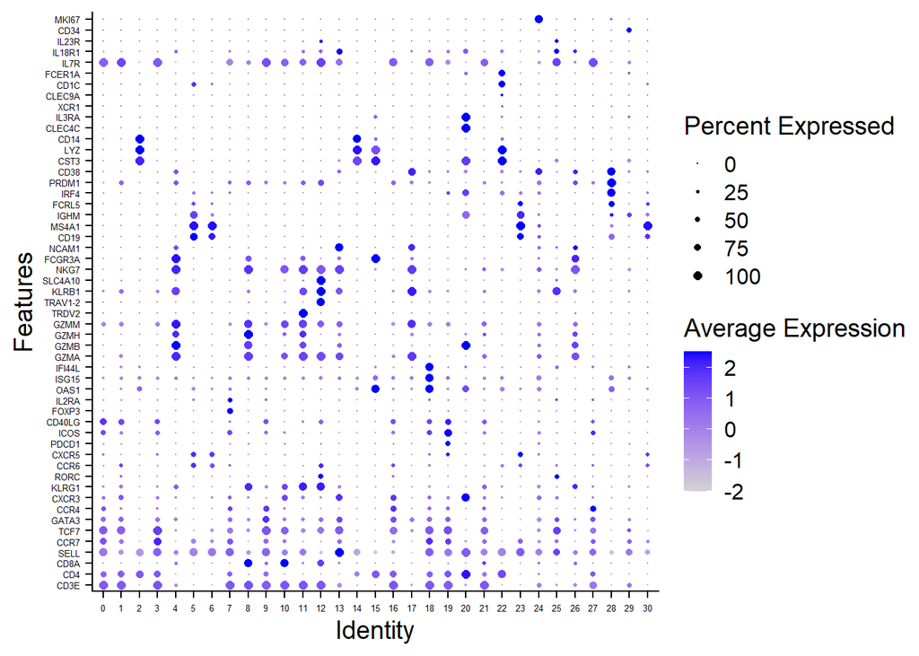

```r
data <- readRDS("data/integrated.rds")

DefaultAssay(data) <- "RNA"
Markers <- c('CD3E','CD4','CD8A','SELL','CCR7','TCF7','GATA3','CCR4','CXCR3','KLRG1','RORC','CCR6','CXCR5','PDCD1','ICOS',
            'CD40LG','FOXP3','IL2RA','OAS1','ISG15','IFI44L','GZMA','GZMB','GZMH','GZMM','TRDV2','TRAV1-2','KLRB1','SLC4A10',
            'NKG7', 'FCGR3A','NCAM1','CD19','MS4A1','IGHM','FCRL5','IRF4','PRDM1','CD38','CST3','LYZ','CD14','CLEC4C','IL3RA',
            'XCR1', 'CLEC9A','CD1C','FCER1A','IL7R','IL18R1','IL23R','CD34','MKI67')
DotPlot(data, features = Markers, dot.min = 0, dot.scale = 2) +coord_flip() +
  theme(axis.text = element_text(size = 5))
```

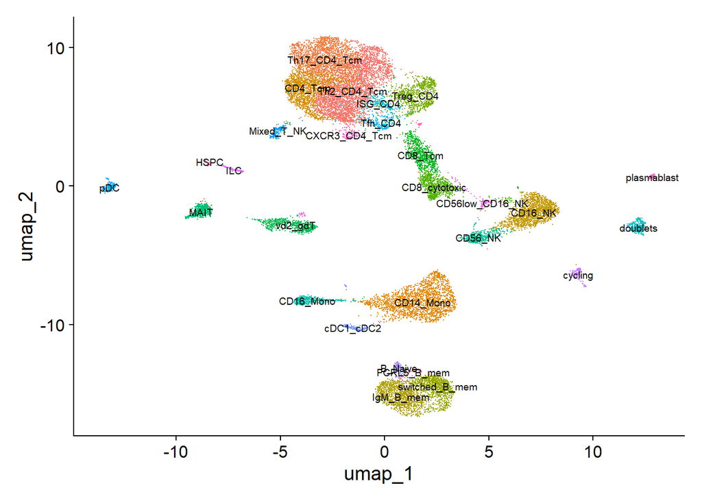

```r
new.cluster.ids <- c(`0` = "Th2_CD4_Tcm",
                     `1` = "Th17_CD4_Tcm",
                     `2` = "CD14_Mono",
                     `3` = "CD4_Tcm",
                     `4` = "CD16_NK",
                     `5` = "IgM_B_mem",
                     `6` = "switched_B_mem",
                     `7` = "Treg_CD4",
                     `8` = "CD8_cytotoxic",
                     `9` = "Th2_CD4_Tcm",
                     `10` = "CD8_Tcm",
                     `11` = "vd2_gdT",
                     `12` = "MAIT",
                     `13` = "CD56_NK",
                     `14` = "CD14_Mono",
                     `15` = "CD16_Mono",
                     `16` = "Th2_CD4_Tcm",
                     `17` = "doublets",
                     `18` = "ISG_CD4",
                     `19` = "Tfh_CD4",
                     `20` = "pDC",
                     `21` = "Mixed_T_NK",
                     `22` = "cDC1_cDC2",
                     `23` = "B_Naive",
                     `24` = "cycling",
                     `25` = "ILC",
                     `26` = "CD56low_CD16_NK",
                     `27` = "CXCR3_CD4_Tcm",
                     `28` = "plasmablast",
                     `29` = "HSPC",
                     `30` = "FCRL5_B_mem"
                     )
names(new.cluster.ids) <- levels(data)
data <- RenameIdents(data, new.cluster.ids)
DimPlot(data, reduction = "umap", label = TRUE, label.size = 2.5) + NoLegend()
```

```r
head(data@meta.data)
```

```
##                             orig.ident nCount_RNA nFeature_RNA         sample
## AAACCTGCAGACGCTC-1_1_1_1 SeuratProject       9435         2826 Blood, donor 1
## AAACCTGGTCTCTTTA-1_1_1_1 SeuratProject       9396         3074 Blood, donor 1
## AAACGGGAGATGGCGT-1_1_1_1 SeuratProject      17748         2766 Blood, donor 1
## AAACGGGCAAACGCGA-1_1_1_1 SeuratProject      25129         4108 Blood, donor 1
## AAACGGGGTCTGCCAG-1_1_1_1 SeuratProject      15509         2744 Blood, donor 1
## AAAGATGAGGTAGCTG-1_1_1_1 SeuratProject      18884         3448 Blood, donor 1
##                                    tissue   donor percent.mt filter
## AAACCTGCAGACGCTC-1_1_1_1 peripheral blood donor 1  1.8335983   keep
## AAACCTGGTCTCTTTA-1_1_1_1 peripheral blood donor 1  1.7667092   keep
## AAACGGGAGATGGCGT-1_1_1_1 peripheral blood donor 1  0.5183683   keep
## AAACGGGCAAACGCGA-1_1_1_1 peripheral blood donor 1  0.7879343   keep
## AAACGGGGTCTGCCAG-1_1_1_1 peripheral blood donor 1  0.9155974   keep
## AAAGATGAGGTAGCTG-1_1_1_1 peripheral blood donor 1  1.4509638   keep
##                          unintegrated_clusters seurat_clusters RNA_snn_res.1.2
## AAACCTGCAGACGCTC-1_1_1_1                    11               8               8
## AAACCTGGTCTCTTTA-1_1_1_1                     4               4               4
## AAACGGGAGATGGCGT-1_1_1_1                     1              14              14
## AAACGGGCAAACGCGA-1_1_1_1                     1               2               2
## AAACGGGGTCTGCCAG-1_1_1_1                     7               3               3
## AAAGATGAGGTAGCTG-1_1_1_1                     3               1               1
```

# Subcluster DCs

Note that at this point DCs can’t be separated into cDC1 and cDC2, so we need to do subclustering

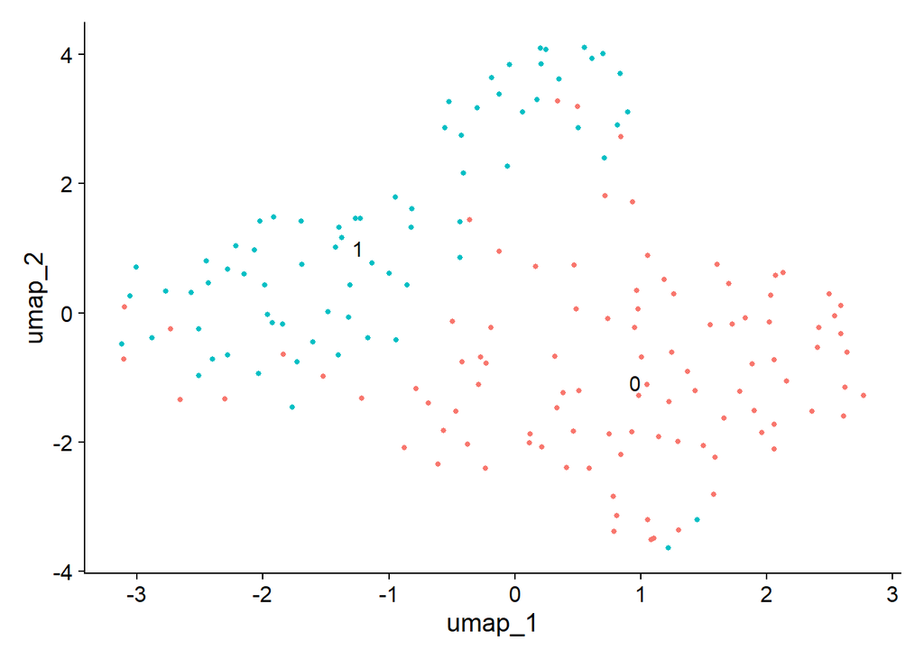

```r
sub.cells <- subset(data, idents = "cDC1_cDC2")
DefaultAssay(sub.cells)<-"RNA"
f = "obj.Rdata"
if(!file.exists(f)){
  sub.cells = sub.cells %>%
  NormalizeData() %>%
  FindVariableFeatures() %>%
  ScaleData(features = c('CLEC9A','XCR1','FCER1A','CD1C')) %>%
  RunPCA(features = c('CLEC9A','XCR1','FCER1A','CD1C'))  %>%
  FindNeighbors(dims = 1:45) %>%
  FindClusters(resolution = 0.5) %>%
  RunUMAP(dims = 1:45)
  save(sub.cells,file = f)
}
load(f)
DimPlot(sub.cells, reduction = 'umap',label = T)+NoLegend()
```

```r
sub.cells
```

```
## An object of class Seurat
## 22198 features across 172 samples within 1 assay
## Active assay: RNA (22198 features, 2000 variable features)
##  3 layers present: data, counts, scale.data
##  4 dimensional reductions calculated: pca, umap.unintegrated, harmony, umap
```

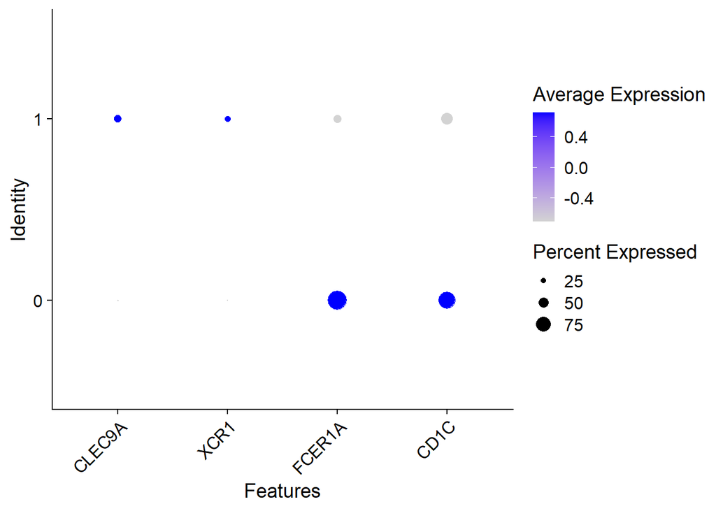

```r
#Visualize marker genes
DefaultAssay(sub.cells)<-"RNA"
DC_markers<-c('CLEC9A','XCR1','FCER1A','CD1C')
DotPlot(sub.cells,features = DC_markers) + RotatedAxis()
```

```r
#Annotate and put back to big umap
sub.cells@meta.data$annotation <- ifelse(sub.cells@meta.data$seurat_clusters == 0, "cDC2", "cDC1")
head(sub.cells@meta.data)
```

```
##                             orig.ident nCount_RNA nFeature_RNA         sample
## ATTGGACCACGGATAG-1_1_1_1 SeuratProject      35038         5857 Blood, donor 1
## CAAGGCCGTGTGCCTG-1_1_1_1 SeuratProject      30235         5353 Blood, donor 1
## CACTCCAAGCGATCCC-1_1_1_1 SeuratProject      28323         4825 Blood, donor 1
## CAGCCGAAGGTGTGGT-1_1_1_1 SeuratProject      38982         6680 Blood, donor 1
## CCACGGACAAAGGCGT-1_1_1_1 SeuratProject      24264         4737 Blood, donor 1
## CCTTACGTCTTTACGT-1_1_1_1 SeuratProject      25173         5157 Blood, donor 1
##                                    tissue   donor percent.mt filter
## ATTGGACCACGGATAG-1_1_1_1 peripheral blood donor 1   1.549746   keep
## CAAGGCCGTGTGCCTG-1_1_1_1 peripheral blood donor 1   1.012072   keep
## CACTCCAAGCGATCCC-1_1_1_1 peripheral blood donor 1   1.066271   keep
## CAGCCGAAGGTGTGGT-1_1_1_1 peripheral blood donor 1   1.611000   keep
## CCACGGACAAAGGCGT-1_1_1_1 peripheral blood donor 1   1.854599   keep
## CCTTACGTCTTTACGT-1_1_1_1 peripheral blood donor 1   2.709252   keep
##                          unintegrated_clusters seurat_clusters RNA_snn_res.1.2
## ATTGGACCACGGATAG-1_1_1_1                    21               0              22
## CAAGGCCGTGTGCCTG-1_1_1_1                    21               0              22
## CACTCCAAGCGATCCC-1_1_1_1                    21               0              22
## CAGCCGAAGGTGTGGT-1_1_1_1                    21               0              22
## CCACGGACAAAGGCGT-1_1_1_1                    21               0              22
## CCTTACGTCTTTACGT-1_1_1_1                    21               0              22
##                          RNA_snn_res.0.5 annotation
## ATTGGACCACGGATAG-1_1_1_1               0       cDC2
## CAAGGCCGTGTGCCTG-1_1_1_1               0       cDC2
## CACTCCAAGCGATCCC-1_1_1_1               0       cDC2
## CAGCCGAAGGTGTGGT-1_1_1_1               0       cDC2
## CCACGGACAAAGGCGT-1_1_1_1               0       cDC2
## CCTTACGTCTTTACGT-1_1_1_1               0       cDC2
```

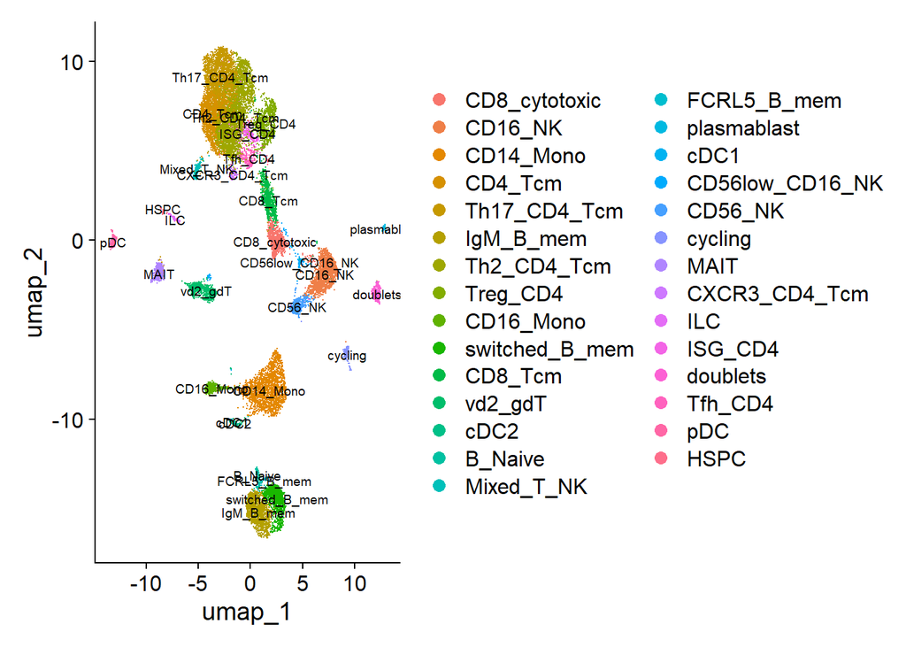

```r
data@meta.data$annotation = as.character(Idents(data))
data@meta.data$annotation = ifelse(data@meta.data$annotation=="cDC1_cDC2",
       sub.cells@meta.data$annotation[match(colnames(data@meta.data),colnames(sub.cells@meta.data))],
       data@meta.data$annotation)
Idents(data) = data@meta.data$annotation
DimPlot(data,reduction = "umap", label = T, label.size = 2.5)
```

```r
table(data@meta.data$annotation)
```

```
##
##         B_Naive       CD14_Mono       CD16_Mono         CD16_NK         CD4_Tcm
##             141            2101             371            1493            1624
##         CD56_NK CD56low_CD16_NK   CD8_cytotoxic         CD8_Tcm            cDC1
##             432             114             876             766              20
##            cDC2   CXCR3_CD4_Tcm         cycling        doublets     FCRL5_B_mem
##             152             106             140             333              43
##            HSPC       IgM_B_mem             ILC         ISG_CD4            MAIT
##              63            1216             128             260             466
##      Mixed_T_NK             pDC     plasmablast  switched_B_mem         Tfh_CD4
##             177             222              75             976             225
##    Th17_CD4_Tcm     Th2_CD4_Tcm        Treg_CD4         vd2_gdT
##            2147            3412             915             693
```

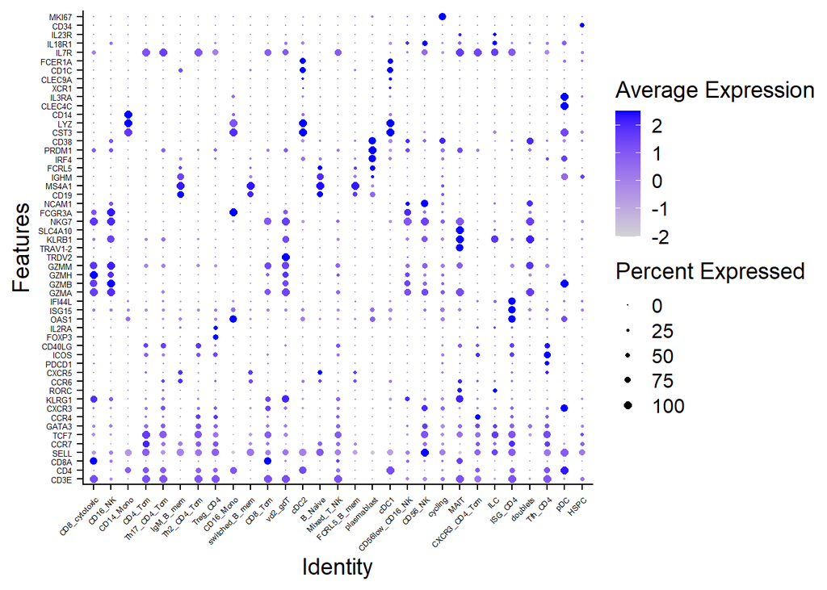

```r
DotPlot(data, features = Markers, dot.min = 0, dot.scale = 2) +coord_flip() +
  theme(axis.text = element_text(size = 5)) + theme(axis.text.x = element_text(angle = 45, hjust = 1))
```

```r
saveRDS(data,"data/alldata_annotated.rds")
```

# Compare Azimuth annotation with unsupervised annotation

If the internet connection is poor, you may need to manually download reference to working directory and install it. `install.packages("tonsilref.SeuratData_2.0.0.tar.gz", repos = NULL, type = "source")` Since I have two sample type (blood and lymph node), I tried two reference, PBMC and tonsil.

# PBMC reference

```r
data<-readRDS("data/alldata_annotated.rds")

DefaultAssay(data)<-"RNA"
data_pbmc_ref<-RunAzimuth(data, reference = "pbmcref")
head(data_pbmc_ref@meta.data)
```

```
##                             orig.ident nCount_RNA nFeature_RNA         sample
## AAACCTGCAGACGCTC-1_1_1_1 SeuratProject       9435         2826 Blood, donor 1
## AAACCTGGTCTCTTTA-1_1_1_1 SeuratProject       9396         3074 Blood, donor 1
## AAACGGGAGATGGCGT-1_1_1_1 SeuratProject      17748         2766 Blood, donor 1
## AAACGGGCAAACGCGA-1_1_1_1 SeuratProject      25129         4108 Blood, donor 1
## AAACGGGGTCTGCCAG-1_1_1_1 SeuratProject      15509         2744 Blood, donor 1
## AAAGATGAGGTAGCTG-1_1_1_1 SeuratProject      18884         3448 Blood, donor 1
##                                    tissue   donor percent.mt filter
## AAACCTGCAGACGCTC-1_1_1_1 peripheral blood donor 1  1.8335983   keep
## AAACCTGGTCTCTTTA-1_1_1_1 peripheral blood donor 1  1.7667092   keep
## AAACGGGAGATGGCGT-1_1_1_1 peripheral blood donor 1  0.5183683   keep
## AAACGGGCAAACGCGA-1_1_1_1 peripheral blood donor 1  0.7879343   keep
## AAACGGGGTCTGCCAG-1_1_1_1 peripheral blood donor 1  0.9155974   keep
## AAAGATGAGGTAGCTG-1_1_1_1 peripheral blood donor 1  1.4509638   keep
##                          unintegrated_clusters seurat_clusters RNA_snn_res.1.2
## AAACCTGCAGACGCTC-1_1_1_1                    11               8               8
## AAACCTGGTCTCTTTA-1_1_1_1                     4               4               4
## AAACGGGAGATGGCGT-1_1_1_1                     1              14              14
## AAACGGGCAAACGCGA-1_1_1_1                     1               2               2
## AAACGGGGTCTGCCAG-1_1_1_1                     7               3               3
## AAAGATGAGGTAGCTG-1_1_1_1                     3               1               1
##                             annotation predicted.celltype.l1.score
## AAACCTGCAGACGCTC-1_1_1_1 CD8_cytotoxic                   0.9053037
## AAACCTGGTCTCTTTA-1_1_1_1       CD16_NK                   1.0000000
## AAACGGGAGATGGCGT-1_1_1_1     CD14_Mono                   1.0000000
## AAACGGGCAAACGCGA-1_1_1_1     CD14_Mono                   0.9124931
## AAACGGGGTCTGCCAG-1_1_1_1       CD4_Tcm                   1.0000000
## AAAGATGAGGTAGCTG-1_1_1_1  Th17_CD4_Tcm                   0.9754514
##                          predicted.celltype.l1 predicted.celltype.l2.score
## AAACCTGCAGACGCTC-1_1_1_1                 CD8 T                   0.9053037
## AAACCTGGTCTCTTTA-1_1_1_1                    NK                   1.0000000
## AAACGGGAGATGGCGT-1_1_1_1                 other                   1.0000000
## AAACGGGCAAACGCGA-1_1_1_1                 other                   0.9124931
## AAACGGGGTCTGCCAG-1_1_1_1                 CD4 T                   0.8727135
## AAAGATGAGGTAGCTG-1_1_1_1                 CD4 T                   0.9754514
##                          predicted.celltype.l2 predicted.celltype.l3.score
## AAACCTGCAGACGCTC-1_1_1_1               CD8 TEM                   0.8956548
## AAACCTGGTCTCTTTA-1_1_1_1                    NK                   0.7784108
## AAACGGGAGATGGCGT-1_1_1_1                 Eryth                   1.0000000
## AAACGGGCAAACGCGA-1_1_1_1                 Eryth                   0.9124931
## AAACGGGGTCTGCCAG-1_1_1_1               CD4 TCM                   0.7880718
## AAAGATGAGGTAGCTG-1_1_1_1               CD4 TCM                   0.5668921
##                          predicted.celltype.l3 mapping.score
## AAACCTGCAGACGCTC-1_1_1_1             CD8 TEM_2     0.8915654
## AAACCTGGTCTCTTTA-1_1_1_1                  NK_2     0.6870798
## AAACGGGAGATGGCGT-1_1_1_1                 Eryth     0.5875810
## AAACGGGCAAACGCGA-1_1_1_1                 Eryth     0.7396500
## AAACGGGGTCTGCCAG-1_1_1_1             CD4 TCM_1     0.6271922
## AAAGATGAGGTAGCTG-1_1_1_1             CD4 TCM_1     0.9080854
```

```r
data_pbmc_ref
```

```
## An object of class Seurat
## 22293 features across 19687 samples within 4 assays
## Active assay: RNA (22198 features, 2000 variable features)
##  3 layers present: data, counts, scale.data
##  3 other assays present: prediction.score.celltype.l1, prediction.score.celltype.l2, prediction.score.celltype.l3
##  6 dimensional reductions calculated: pca, umap.unintegrated, harmony, umap, integrated_dr, ref.umap
```

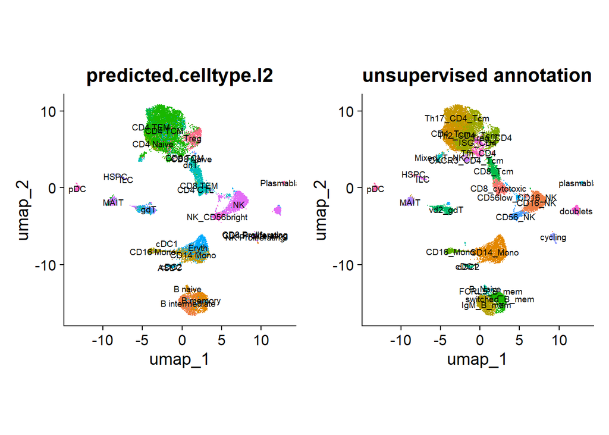

```r
p1<-DimPlot(data_pbmc_ref, reduction = "umap", group.by = "predicted.celltype.l2", label = TRUE, label.size = 2.5) +
  NoLegend() + theme(aspect.ratio = 1)
p2<-DimPlot(data, reduction = "umap", label = T, label.size = 2.5) +ggtitle("unsupervised annotation") +
  NoLegend() + theme(aspect.ratio = 1)
p1+p2
```

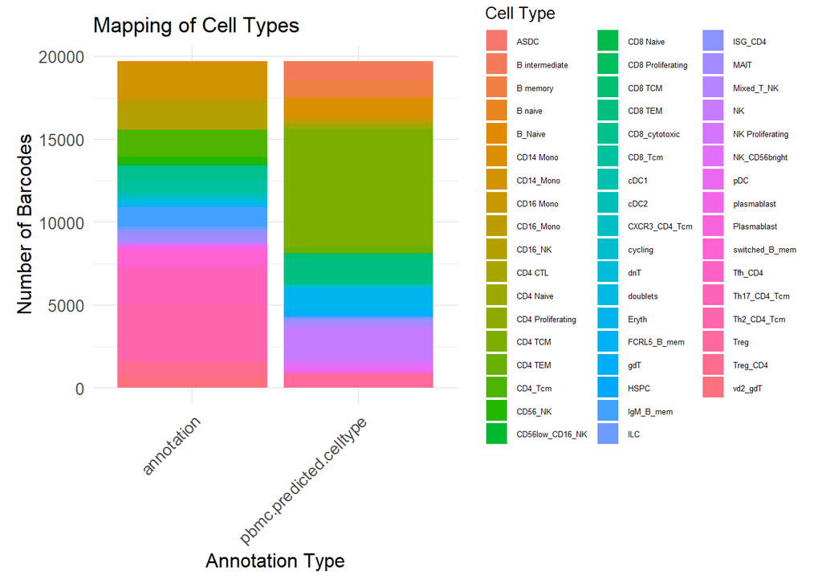

```r
meta.data1 <- data_pbmc_ref@meta.data[, c("annotation", "predicted.celltype.l2")]
meta.data1 <- meta.data1 %>%
  rename(pbmc.predicted.celltype = predicted.celltype.l2)

metadata_long1 <- meta.data1 %>%
  pivot_longer(cols = c("annotation", "pbmc.predicted.celltype"),
               names_to = "Type", values_to = "CellType")

counts1 <- metadata_long1 %>%
  group_by(Type, CellType) %>%
  summarise(Count = n(), .groups = "drop")

ggplot(counts1, aes(x = Type, y = Count, fill = CellType)) +
  geom_bar(stat = "identity", position = "stack") +
  theme_minimal() +
  labs(x = "Annotation Type", y = "Number of Barcodes", fill = "Cell Type", title = "Mapping of Cell Types") +
  theme(
    axis.text.x = element_text(angle = 45, hjust = 1),
    legend.text = element_text(size = 5),  # Adjust legend text size
    legend.title = element_text(size = 10),  # Adjust legend title size
    legend.key.size = unit(0.5, "cm"),      # Adjust legend key size
    legend.position = "right",              # Position legend to the right
    plot.margin = margin(10, 10, 10, 10),   # Adjust plot margins for more space
    axis.title = element_text(size = 12),   # Increase axis title size (optional)
    axis.text = element_text(size = 10)     # Adjust axis text size (optional)
  )
```

```r
table(data_pbmc_ref@meta.data$annotation)
```

```
##
##         B_Naive       CD14_Mono       CD16_Mono         CD16_NK         CD4_Tcm
##             141            2101             371            1493            1624
##         CD56_NK CD56low_CD16_NK   CD8_cytotoxic         CD8_Tcm            cDC1
##             432             114             876             766              20
##            cDC2   CXCR3_CD4_Tcm         cycling        doublets     FCRL5_B_mem
##             152             106             140             333              43
##            HSPC       IgM_B_mem             ILC         ISG_CD4            MAIT
##              63            1216             128             260             466
##      Mixed_T_NK             pDC     plasmablast  switched_B_mem         Tfh_CD4
##             177             222              75             976             225
##    Th17_CD4_Tcm     Th2_CD4_Tcm        Treg_CD4         vd2_gdT
##            2147            3412             915             693
```

```r
table(data_pbmc_ref@meta.data$predicted.celltype.l2)
```

```
##
##              ASDC    B intermediate          B memory           B naive
##                 1              1129               983               169
##         CD14 Mono         CD16 Mono           CD4 CTL         CD4 Naive
##              1081               364                56               245
## CD4 Proliferating           CD4 TCM           CD4 TEM         CD8 Naive
##                37              7131               381                30
## CD8 Proliferating           CD8 TCM           CD8 TEM              cDC1
##                 2               281              1540                24
##              cDC2               dnT             Eryth               gdT
##               152                54              1318               352
##              HSPC               ILC              MAIT                NK
##                55               145               469              2052
##  NK Proliferating     NK_CD56bright               pDC       Plasmablast
##                51               372               222                90
##              Treg
##               901
```

```r
heatmap_data <- dcast(data_pbmc_ref@meta.data, annotation ~ predicted.celltype.l2, value.var = "predicted.celltype.l2.score", fun.aggregate = mean, na.rm = TRUE)
rownames(heatmap_data) <- heatmap_data$annotation
cell_scores_matrix <- as.matrix(heatmap_data[, -1])
cell_scores_matrix[is.na(cell_scores_matrix)] <- 0
head(cell_scores_matrix)
```

```
##           ASDC B intermediate  B memory   B naive CD14 Mono CD16 Mono CD4 CTL
## B_Naive      0      0.5890165 0.4657730 0.8907004 0.0000000 0.0000000       0
## CD14_Mono    0      0.6396518 0.7544351 0.0000000 0.8813926 0.5491677       0
## CD16_Mono    0      0.6060555 0.0000000 0.0000000 0.5600398 0.9806752       0
## CD16_NK      0      0.0000000 0.0000000 0.0000000 0.0000000 0.0000000       0
## CD4_Tcm      0      0.0000000 0.0000000 0.0000000 0.0000000 0.0000000       0
## CD56_NK      0      0.0000000 0.0000000 0.0000000 0.0000000 0.0000000       0
##           CD4 Naive CD4 Proliferating   CD4 TCM   CD4 TEM CD8 Naive
## B_Naive   0.0000000                 0 0.0000000 0.0000000  0.000000
## CD14_Mono 0.0000000                 0 0.7623068 0.0000000  0.000000
## CD16_Mono 0.0000000                 0 0.0000000 0.0000000  0.000000
## CD16_NK   0.0000000                 0 0.0000000 0.0000000  0.000000
## CD4_Tcm   0.6086536                 0 0.8477866 0.5035937  0.433636
## CD56_NK   0.0000000                 0 0.0000000 0.0000000  0.000000
##           CD8 Proliferating   CD8 TCM   CD8 TEM cDC1      cDC2       dnT
## B_Naive                   0 0.0000000 0.0000000    0 0.0000000 0.0000000
## CD14_Mono                 0 0.0000000 0.5148623    0 0.7147617 0.0000000
## CD16_Mono                 0 0.0000000 0.0000000    0 0.0000000 0.0000000
## CD16_NK                   0 0.0000000 0.3631004    0 0.0000000 0.0000000
## CD4_Tcm                   0 0.4743092 0.0000000    0 0.0000000 0.3880215
## CD56_NK                   0 0.0000000 0.3276535    0 0.0000000 0.0000000
##               Eryth       gdT HSPC       ILC      MAIT        NK
## B_Naive   0.4759382 0.0000000    0 0.0000000 0.0000000 0.0000000
## CD14_Mono 0.8858704 0.0000000    0 0.8204655 0.0000000 0.9906179
## CD16_Mono 0.6812084 0.0000000    0 0.3061641 0.0000000 0.0000000
## CD16_NK   0.6573706 0.4871832    0 0.7223629 0.3985685 0.9810362
## CD4_Tcm   0.0000000 0.6082225    0 0.0000000 0.0000000 0.0000000
## CD56_NK   0.0000000 0.0000000    0 0.6093900 0.0000000 0.7454734
##           NK Proliferating NK_CD56bright pDC Plasmablast      Treg
## B_Naive          0.0000000     0.0000000   0           0 0.0000000
## CD14_Mono        0.0000000     0.0000000   0           0 0.0000000
## CD16_Mono        0.0000000     0.7501439   0           0 0.0000000
## CD16_NK          0.8403111     0.5568415   0           0 0.2395795
## CD4_Tcm          0.0000000     0.0000000   0           0 0.4171718
## CD56_NK          0.0000000     0.8867240   0           0 0.0000000
```

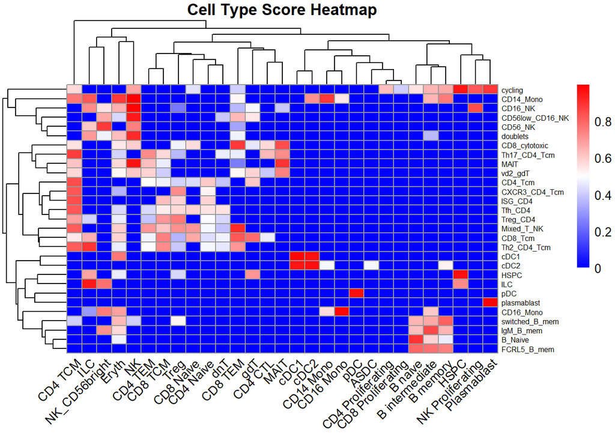

```r
pheatmap(cell_scores_matrix,
         cluster_rows = TRUE,     # Cluster cell types (rows)
         cluster_cols = TRUE,     # Cluster conditions (columns)
         scale = "none",          # Optionally scale the data (e.g., "row" for row normalization)
         color = colorRampPalette(c("blue", "white", "red"))(100),  # Adjust color palette
         na_col = "grey",         # Color for missing values (NA)
         main = "Cell Type Score Heatmap",
         fontsize_row = 6,
         fontsize_col = 10,
         angle_col = 45
)
```

# Tonsil

```r
DefaultAssay(data)<-"RNA"
data_tonsil_ref<-RunAzimuth(data, reference = "tonsilref")
head(data_tonsil_ref@meta.data)
```

```
##                             orig.ident nCount_RNA nFeature_RNA         sample
## AAACCTGCAGACGCTC-1_1_1_1 SeuratProject       9435         2826 Blood, donor 1
## AAACCTGGTCTCTTTA-1_1_1_1 SeuratProject       9396         3074 Blood, donor 1
## AAACGGGAGATGGCGT-1_1_1_1 SeuratProject      17748         2766 Blood, donor 1
## AAACGGGCAAACGCGA-1_1_1_1 SeuratProject      25129         4108 Blood, donor 1
## AAACGGGGTCTGCCAG-1_1_1_1 SeuratProject      15509         2744 Blood, donor 1
## AAAGATGAGGTAGCTG-1_1_1_1 SeuratProject      18884         3448 Blood, donor 1
##                                    tissue   donor percent.mt filter
## AAACCTGCAGACGCTC-1_1_1_1 peripheral blood donor 1  1.8335983   keep
## AAACCTGGTCTCTTTA-1_1_1_1 peripheral blood donor 1  1.7667092   keep
## AAACGGGAGATGGCGT-1_1_1_1 peripheral blood donor 1  0.5183683   keep
## AAACGGGCAAACGCGA-1_1_1_1 peripheral blood donor 1  0.7879343   keep
## AAACGGGGTCTGCCAG-1_1_1_1 peripheral blood donor 1  0.9155974   keep
## AAAGATGAGGTAGCTG-1_1_1_1 peripheral blood donor 1  1.4509638   keep
##                          unintegrated_clusters seurat_clusters RNA_snn_res.1.2
## AAACCTGCAGACGCTC-1_1_1_1                    11               8               8
## AAACCTGGTCTCTTTA-1_1_1_1                     4               4               4
## AAACGGGAGATGGCGT-1_1_1_1                     1              14              14
## AAACGGGCAAACGCGA-1_1_1_1                     1               2               2
## AAACGGGGTCTGCCAG-1_1_1_1                     7               3               3
## AAAGATGAGGTAGCTG-1_1_1_1                     3               1               1
##                             annotation predicted.celltype.l1.score
## AAACCTGCAGACGCTC-1_1_1_1 CD8_cytotoxic                   0.8468988
## AAACCTGGTCTCTTTA-1_1_1_1       CD16_NK                   0.5435546
## AAACGGGAGATGGCGT-1_1_1_1     CD14_Mono                   0.9759557
## AAACGGGCAAACGCGA-1_1_1_1     CD14_Mono                   1.0000000
## AAACGGGGTCTGCCAG-1_1_1_1       CD4_Tcm                   0.6911479
## AAAGATGAGGTAGCTG-1_1_1_1  Th17_CD4_Tcm                   0.5467835
##                          predicted.celltype.l1 predicted.celltype.l2.score
## AAACCTGCAGACGCTC-1_1_1_1                 CD8 T                   0.3441379
## AAACCTGGTCTCTTTA-1_1_1_1                 CD8 T                   0.3701772
## AAACGGGAGATGGCGT-1_1_1_1            Mono/Macro                   0.9759557
## AAACGGGCAAACGCGA-1_1_1_1            Mono/Macro                   1.0000000
## AAACGGGGTCTGCCAG-1_1_1_1             CD4 naive                   0.6911479
## AAAGATGAGGTAGCTG-1_1_1_1             CD4 naive                   0.5467835
##                          predicted.celltype.l2 mapping.score
## AAACCTGCAGACGCTC-1_1_1_1              EM CD8 T     0.9209072
## AAACCTGGTCTCTTTA-1_1_1_1              EM CD8 T     0.8255224
## AAACGGGAGATGGCGT-1_1_1_1             Monocytes     0.7847656
## AAACGGGCAAACGCGA-1_1_1_1             Monocytes     0.7274045
## AAACGGGGTCTGCCAG-1_1_1_1                 Naive     0.7914159
## AAAGATGAGGTAGCTG-1_1_1_1                 Naive     0.9405505
```

```r
data_tonsil_ref
```

```
## An object of class Seurat
## 22357 features across 19687 samples within 3 assays
## Active assay: RNA (22198 features, 2000 variable features)
##  3 layers present: data, counts, scale.data
##  2 other assays present: prediction.score.celltype.l1, prediction.score.celltype.l2
##  6 dimensional reductions calculated: pca, umap.unintegrated, harmony, umap, integrated_dr, ref.umap
```

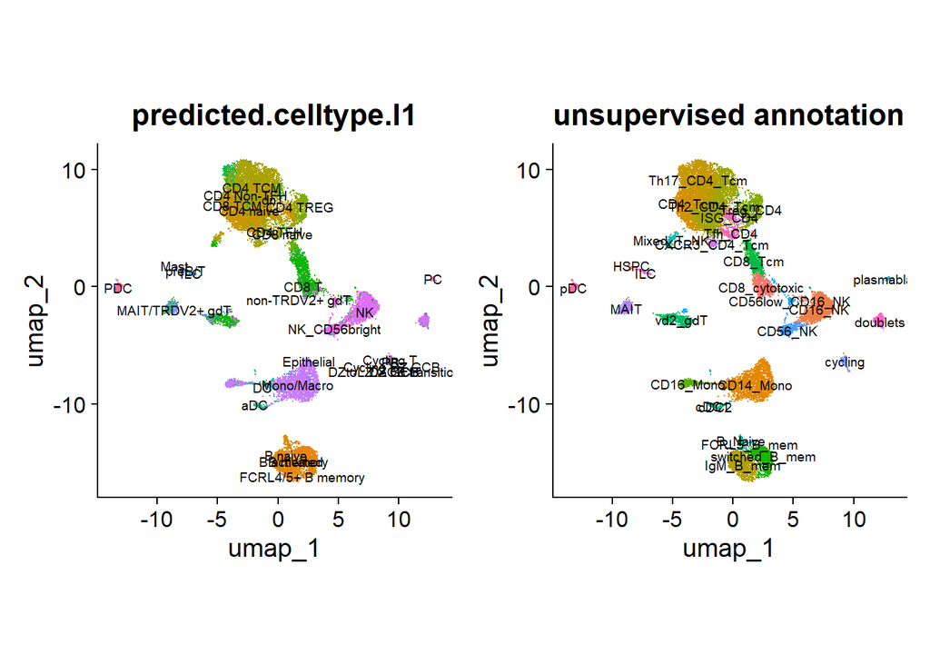

```r
p3<-DimPlot(data_tonsil_ref, reduction = "umap", group.by = "predicted.celltype.l1", label = TRUE, label.size = 2.5) +
  NoLegend() + theme(aspect.ratio = 1)
p4<-DimPlot(data, reduction = "umap", label = T, label.size = 2.5) + ggtitle("unsupervised annotation") +
  NoLegend() + theme(aspect.ratio = 1)
p3+p4
```

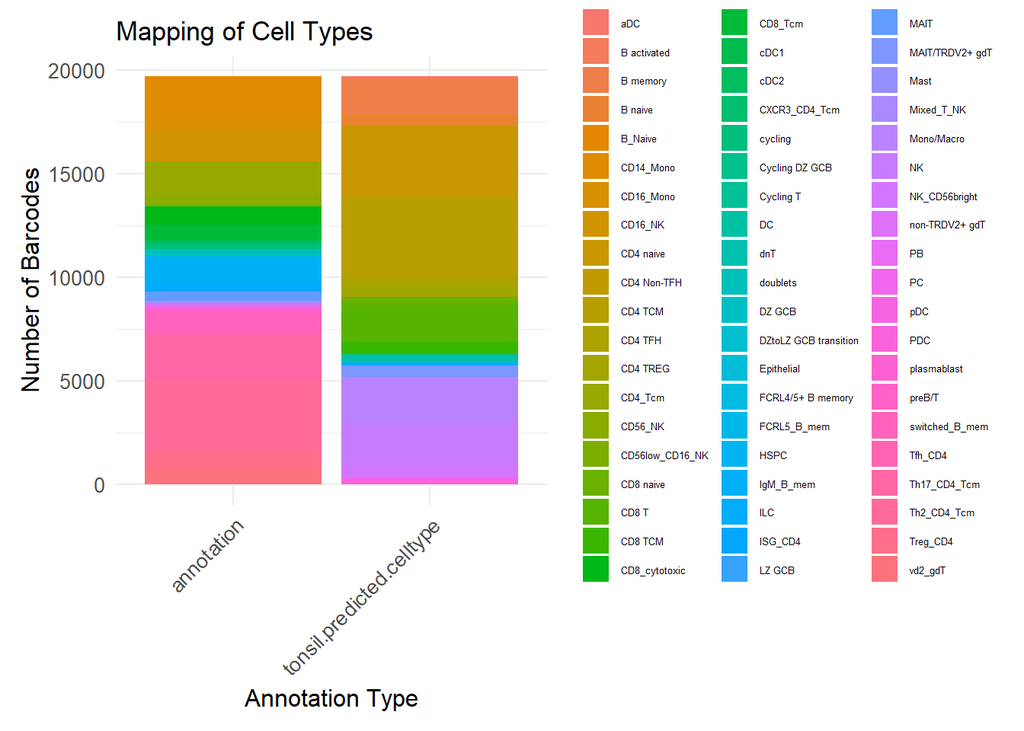

```r
meta.data2 <- data_tonsil_ref@meta.data[, c("annotation", "predicted.celltype.l1")]
meta.data2 <- meta.data2 %>%
  rename(tonsil.predicted.celltype = predicted.celltype.l1)

metadata_long2 <- meta.data2 %>%
  pivot_longer(cols = c("annotation", "tonsil.predicted.celltype"),
               names_to = "Type", values_to = "CellType")

counts2 <- metadata_long2 %>%
  group_by(Type, CellType) %>%
  summarise(Count = n(), .groups = "drop")

ggplot(counts2, aes(x = Type, y = Count, fill = CellType)) +
  geom_bar(stat = "identity", position = "stack") +
  theme_minimal() +
  labs(x = "Annotation Type", y = "Number of Barcodes", fill = "Cell Type", title = "Mapping of Cell Types") +
  theme(
    axis.text.x = element_text(angle = 45, hjust = 1),
    legend.text = element_text(size = 5),  # Adjust legend text size
    legend.title = element_text(size = 10),  # Adjust legend title size
    legend.key.size = unit(0.5, "cm"),      # Adjust legend key size
    legend.position = "right",              # Position legend to the right
    plot.margin = margin(10, 10, 10, 10),   # Adjust plot margins for more space
    axis.title = element_text(size = 12),   # Increase axis title size (optional)
    axis.text = element_text(size = 10)     # Adjust axis text size (optional)
  )
```

```r
table(data_tonsil_ref@meta.data$annotation)
```

```
##
##         B_Naive       CD14_Mono       CD16_Mono         CD16_NK         CD4_Tcm
##             141            2101             371            1493            1624
##         CD56_NK CD56low_CD16_NK   CD8_cytotoxic         CD8_Tcm            cDC1
##             432             114             876             766              20
##            cDC2   CXCR3_CD4_Tcm         cycling        doublets     FCRL5_B_mem
##             152             106             140             333              43
##            HSPC       IgM_B_mem             ILC         ISG_CD4            MAIT
##              63            1216             128             260             466
##      Mixed_T_NK             pDC     plasmablast  switched_B_mem         Tfh_CD4
##             177             222              75             976             225
##    Th17_CD4_Tcm     Th2_CD4_Tcm        Treg_CD4         vd2_gdT
##            2147            3412             915             693
```

```r
table(data_tonsil_ref@meta.data$predicted.celltype.l1)
```

```
##
##                   aDC           B activated              B memory
##                     2                    14                  1794
##               B naive             CD4 naive           CD4 Non-TFH
##                   546                  3486                    42
##               CD4 TCM               CD4 TFH              CD4 TREG
##                  3857                   290                   626
##             CD8 naive                 CD8 T               CD8 TCM
##                   352                  1810                   590
##        Cycling DZ GCB             Cycling T                    DC
##                    10                    33                   318
##                   dnT                DZ GCB DZtoLZ GCB transition
##                    10                     4                     8
##            Epithelial     FCRL4/5+ B memory                   ILC
##                     3                     6                   152
##                LZ GCB       MAIT/TRDV2+ gdT                  Mast
##                     4                   536                     5
##            Mono/Macro                    NK         NK_CD56bright
##                  2300                  1926                   543
##        non-TRDV2+ gdT                    PB                    PC
##                   116                     1                    85
##                   PDC                preB/T
##                   217                     1
```

```r
heatmap_data <- dcast(data_tonsil_ref@meta.data, annotation ~ predicted.celltype.l1, value.var = "predicted.celltype.l1.score", fun.aggregate = mean, na.rm = TRUE)
rownames(heatmap_data) <- heatmap_data$annotation
cell_scores_matrix <- as.matrix(heatmap_data[, -1])
cell_scores_matrix[is.na(cell_scores_matrix)] <- 0
head(cell_scores_matrix)
```

```
##           aDC B activated  B memory   B naive CD4 naive CD4 Non-TFH   CD4 TCM
## B_Naive     0           0 0.6335592 0.8380440 0.0000000    0.000000 0.5396358
## CD14_Mono   0           0 0.5850765 0.3010628 0.1460614    0.000000 0.0000000
## CD16_Mono   0           0 0.0000000 0.0000000 0.0000000    0.000000 0.0000000
## CD16_NK     0           0 0.0000000 0.0000000 0.3127777    0.000000 0.0000000
## CD4_Tcm     0           0 0.0000000 0.0000000 0.7634195    0.629894 0.6426959
## CD56_NK     0           0 0.0000000 0.0000000 0.0000000    0.000000 0.0000000
##             CD4 TFH  CD4 TREG CD8 naive     CD8 T   CD8 TCM Cycling DZ GCB
## B_Naive   0.0000000 0.0000000 0.0000000 0.0000000 0.0000000              0
## CD14_Mono 0.0000000 0.0000000 0.0000000 0.0000000 0.0000000              0
## CD16_Mono 0.0000000 0.0000000 0.2745333 0.0000000 0.0000000              0
## CD16_NK   0.0000000 0.0000000 0.0000000 0.5600321 0.3294266              0
## CD4_Tcm   0.3657775 0.4950219 0.5060311 0.0000000 0.4476519              0
## CD56_NK   0.0000000 0.0000000 0.0000000 0.4105478 0.3598852              0
##           Cycling T        DC       dnT DZ GCB DZtoLZ GCB transition Epithelial
## B_Naive           0 0.0000000 0.0000000      0                     0  0.0000000
## CD14_Mono         0 0.6285619 0.0000000      0                     0  0.3129261
## CD16_Mono         0 0.6098406 0.0000000      0                     0  0.0000000
## CD16_NK           0 0.0000000 0.0000000      0                     0  0.0000000
## CD4_Tcm           0 0.0000000 0.3607115      0                     0  0.0000000
## CD56_NK           0 0.0000000 0.0000000      0                     0  0.0000000
##           FCRL4/5+ B memory       ILC LZ GCB MAIT/TRDV2+ gdT      Mast
## B_Naive                   0 0.0000000      0       0.0000000 0.0000000
## CD14_Mono                 0 0.2536066      0       0.2289849 0.3167679
## CD16_Mono                 0 0.4774493      0       0.3479988 0.0000000
## CD16_NK                   0 0.7759129      0       0.4583060 0.0000000
## CD4_Tcm                   0 0.0000000      0       0.0000000 0.0000000
## CD56_NK                   0 0.9771146      0       0.4464267 0.0000000
##           Mono/Macro        NK NK_CD56bright non-TRDV2+ gdT PB PC PDC preB/T
## B_Naive    0.0000000 0.0000000     0.0000000      0.0000000  0  0   0      0
## CD14_Mono  0.9425558 0.5815717     0.0000000      0.0000000  0  0   0      0
## CD16_Mono  0.7180902 0.0000000     0.6920385      0.0000000  0  0   0      0
## CD16_NK    0.0000000 0.6930215     0.4942578      0.0000000  0  0   0      0
## CD4_Tcm    0.0000000 0.0000000     0.3289039      0.0000000  0  0   0      0
## CD56_NK    0.0000000 0.6001699     0.7044107      0.3855985  0  0   0      0
```

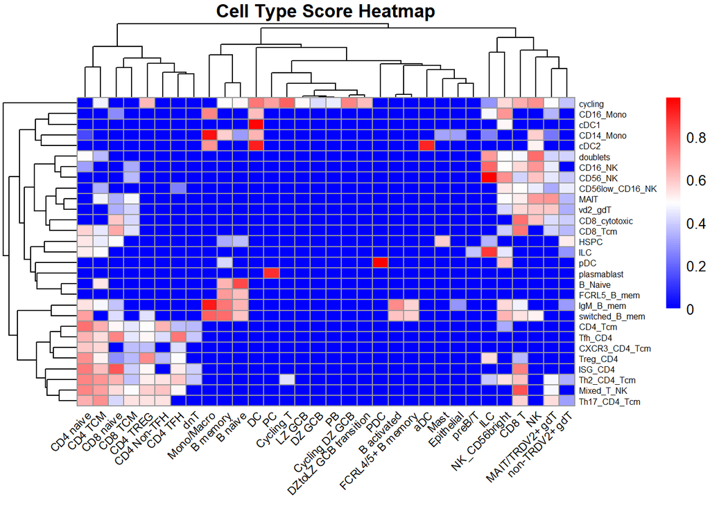

```r
pheatmap(cell_scores_matrix,
         cluster_rows = TRUE,     # Cluster cell types (rows)
         cluster_cols = TRUE,     # Cluster conditions (columns)
         scale = "none",          # Optionally scale the data (e.g., "row" for row normalization)
         color = colorRampPalette(c("blue", "white", "red"))(100),  # Adjust color palette
         na_col = "grey",         # Color for missing values (NA)
         main = "Cell Type Score Heatmap",
         fontsize_row = 6,
         fontsize_col = 8,
         angle_col = 45
)
```

```r
saveRDS(data_pbmc_ref, "data/data_pbmc_ref.rds")
saveRDS(data_tonsil_ref, "data/data_tonsil_ref.rds")
```

# Annotate DC subclusters using new annotation

I think using PBMC reference gives a better annotation of DC subsets, but I don’t want to lose other annotations. So I will replace DC cells with new annotations, but keep the other cell types unchanged

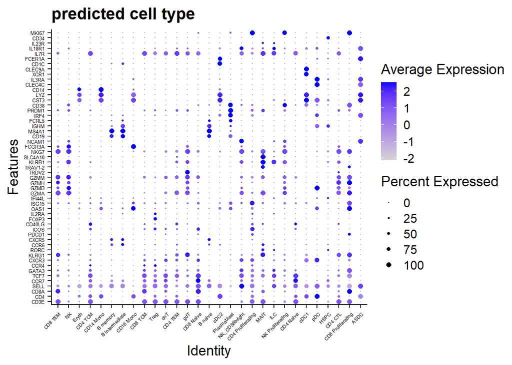

```r
Idents(data_pbmc_ref)<-data_pbmc_ref@meta.data$predicted.celltype.l2
DotPlot(data_pbmc_ref, features = Markers, dot.min = 0, dot.scale = 2) +coord_flip() +
  theme(axis.text = element_text(size = 5)) + theme(axis.text.x = element_text(angle = 45, hjust = 1)) + ggtitle("predicted cell type")
```

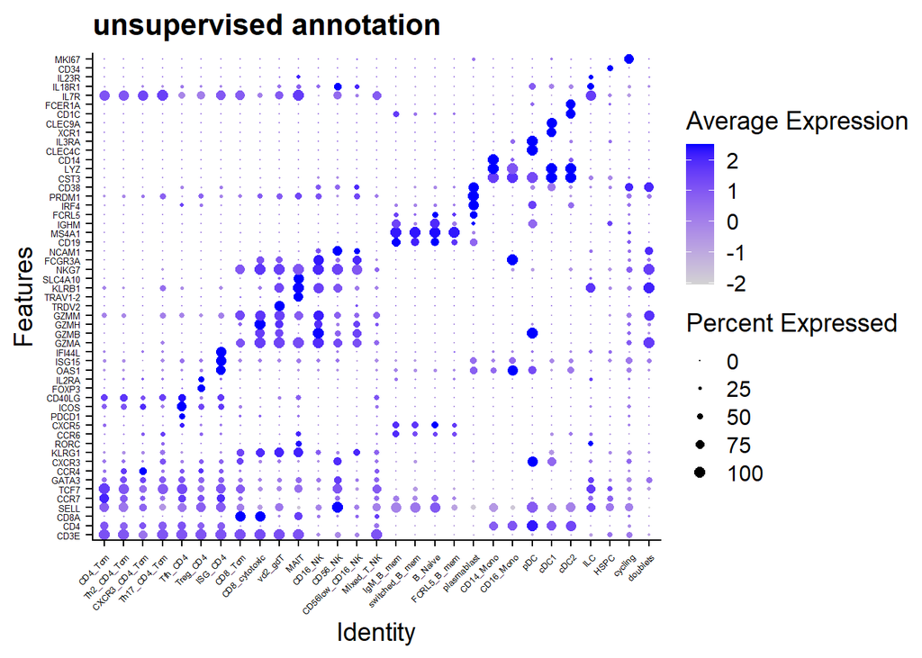

```r
data_pbmc_ref@meta.data$annotation[
  data_pbmc_ref@meta.data$predicted.celltype.l2 %in% c("cDC1", "cDC2")
] <- data_pbmc_ref@meta.data$predicted.celltype.l2[
  data_pbmc_ref@meta.data$predicted.celltype.l2 %in% c("cDC1", "cDC2")
]

Idents(data_pbmc_ref) <- data_pbmc_ref@meta.data$annotation
Idents(data_pbmc_ref) <- factor(Idents(data_pbmc_ref), levels = c("CD4_Tcm",
                                                                  "Th2_CD4_Tcm",
                                                                  "CXCR3_CD4_Tcm",
                                                                  "Th17_CD4_Tcm",
                                                                  "Tfh_CD4",
                                                                  "Treg_CD4",
                                                                  "ISG_CD4",
                                                                  "CD8_Tcm",
                                                                  "CD8_cytotoxic",
                                                                  "vd2_gdT",
                                                                  "MAIT",
                                                                  "CD16_NK",
                                                                  "CD56_NK",
                                                                  "CD56low_CD16_NK",
                                                                  "Mixed_T_NK",
                                                                  "IgM_B_mem",
                                                                  "switched_B_mem",
                                                                  "B_Naive",
                                                                  "FCRL5_B_mem",
                                                                  "plasmablast",
                                                                  "CD14_Mono",
                                                                  "CD16_Mono",
                                                                  "pDC",
                                                                  "cDC1",
                                                                  "cDC2",
                                                                  "ILC",
                                                                  "HSPC",
                                                                  "cycling",
                                                                  "doublets"))


DotPlot(data_pbmc_ref, features = Markers, dot.min = 0, dot.scale = 2.5) +coord_flip() +
  theme(axis.text = element_text(size = 5)) + theme(axis.text.x = element_text(angle = 45, hjust = 1)) + ggtitle("unsupervised annotation")
```

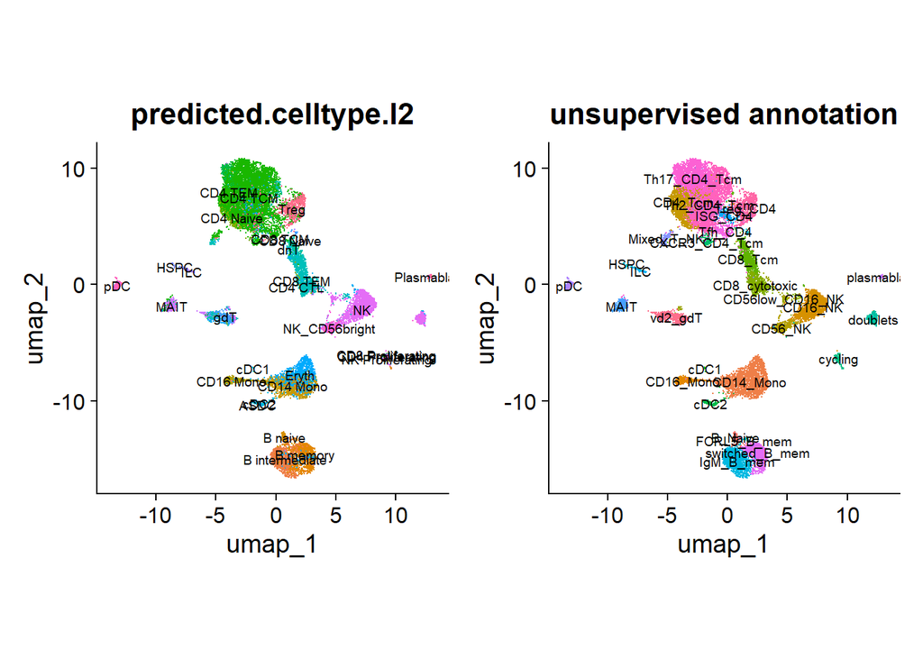

```r
p5<-DimPlot(data_pbmc_ref, reduction = "umap", group.by = "predicted.celltype.l2", label = TRUE, label.size = 2.5) +
  NoLegend() + theme(aspect.ratio = 1)
p6<-DimPlot(data_pbmc_ref, reduction = "umap", group.by = "annotation", label = TRUE, label.size = 2.5) +
  NoLegend() + theme(aspect.ratio = 1) + ggtitle("unsupervised annotation")
p5+p6
```